# Prediction Assignment

Marenco Kemp

29/08/2019

## Load libraries

```r
library(caret)
library(rpart)
library(rpart.plot)
library(randomForest)
library(corrplot)
library(gbm)
library(visdat)
```

## Load the training & test data

```r
train_source <- read.csv('./pml-training.csv', header=TRUE)
test_source <- read.csv('./pml-testing.csv', header=TRUE)
dim(train_source)
```

```
## [1] 19622   160
```

```r
dim(test_source)
```

```
## [1]  20 160
```

There are 19622 observations in the training data and 160 variables. The test data only contains 20 observations and also 160 variables.

Can we remove any variables in order to simplify model?

Actual specific usage data line the given files only start at variable number 8. The ones prior will intuitively not help us predict how well they do the exercise (classe) so variables 1 to 7 will be removed.

```r
table(is.na(train_source))
```

```
##
##   FALSE    TRUE
## 1852048 1287472
```

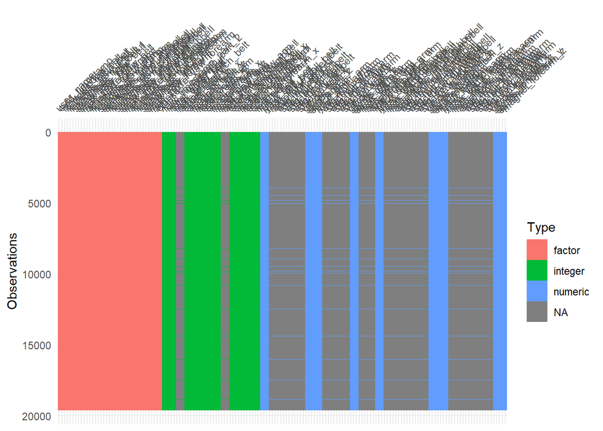

```r
vis_dat(train_source, warn_large_data = FALSE, palette="default")
```

Let’s remove any variables which have more than 95% of their data as NA and as discussed before, also remove the first 7 variables.

```r
# Remove variables with 'Nearly Zero Variance'
nzv <- nearZeroVar(train_source)
train_source  <- train_source[, -nzv]
test_source  <- test_source[, -nzv]

# Remove NA values
mostlyNA <- sapply(train_source, function(x) mean(is.na(x))) > 0.95
train_source <- train_source[, mostlyNA == FALSE]
test_source <- test_source[, mostlyNA == FALSE]

# Remove first 7 variables
train_source <- train_source[, -c(1:7)]
test_source <- test_source[, -c(1:7)]
```

This will leave us with 52 variables.

## Splitting the data for modeling.

We partition the training dataset (train_Data_source) into two sets: 60% of the training data for the modeling process and the remaining 40% for the test set. The other data file (test_source) is not modified and will be used to predict the right answers for the quiz.

```r
in_train  <- createDataPartition(train_source$classe, p = 0.6, list = FALSE)
train_set <- train_source[in_train, ]
test_set  <- train_source[-in_train, ]
```

## Building the prediction model

# Cross validation

Here we set the cross-validation parameters for the models:

```r
# decision tree
fitControlDT <- rpart.control(method = "cv", number = 3, verboseIter = FALSE)

# random forest
fitControlRF <- trainControl(method = "cv", number = 3, verboseIter = FALSE, allowParallel = TRUE)

# generalized boosted model
fitControlGBM <- trainControl(method = "repeatedcv", number = 3, repeats = 1, verboseIter = FALSE, allowParallel = TRUE)
```

# Decision Tree

Build the model and the corresponding decision tree diagram.

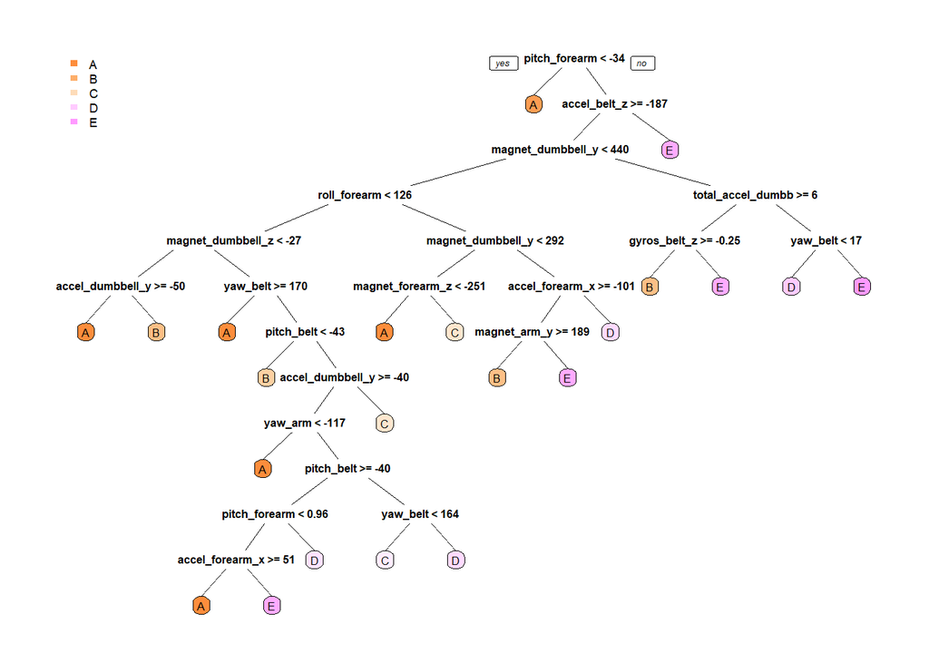

```r
set.seed(1234)
mod_fit_dt <- rpart(as.factor(classe) ~ .,data = train_set,control = fitControlDT, method = "class")

prp(mod_fit_dt, faclen = 0, box.palette = "OrPu", cex = 0.50, legend.x = 0, legend.y = 1, legend.cex = 1)
```

Validate the Decision Tree model on the test set (testSet) to determine how well it performed and the accuracy of the results.

```r
prediction_dt <- predict(mod_fit_dt, newdata = test_set, type = "class")
conf_matrix_dt <- confusionMatrix(prediction_dt, test_set$classe)
print(conf_matrix_dt)
```

```
## Confusion Matrix and Statistics
##
##           Reference
## Prediction    A    B    C    D    E
##          A 1960  209   12  120   39
##          B   54  822  128   42  220
##          C   59  171  999  189  226
##          D  136  259  191  868  168
##          E   23   57   38   67  789
##
## Overall Statistics
##
##                Accuracy : 0.6931
##                  95% CI : (0.6828, 0.7033)
##     No Information Rate : 0.2845
##     P-Value [Acc > NIR] : < 2.2e-16
##
##                   Kappa : 0.6119
##
##  Mcnemar's Test P-Value : < 2.2e-16
##
## Statistics by Class:
##
##                      Class: A Class: B Class: C Class: D Class: E
## Sensitivity            0.8781   0.5415   0.7303   0.6750   0.5472
## Specificity            0.9323   0.9298   0.9004   0.8851   0.9711
## Pos Pred Value         0.8376   0.6493   0.6077   0.5351   0.8101
## Neg Pred Value         0.9506   0.8942   0.9405   0.9328   0.9050
## Prevalence             0.2845   0.1935   0.1744   0.1639   0.1838
## Detection Rate         0.2498   0.1048   0.1273   0.1106   0.1006
## Detection Prevalence   0.2982   0.1614   0.2095   0.2067   0.1241
## Balanced Accuracy      0.9052   0.7357   0.8153   0.7800   0.7591
```

The results from the confusion matrix for the Decision Tree model show a predicted accuracy of 0.7 giving an out-of-sample error rate of 0.3 which is high.

# Random Forest

Here we build the random forest model and we hope to see better results.

```r
set.seed(1234)

mod_fit_rf <- train(classe ~ .,method="rf", data=train_source, trControl=fitControlRF, verbose = FALSE)

print(mod_fit_rf$finalModel)
```

```
##
## Call:
##  randomForest(x = x, y = y, mtry = param$mtry, verbose = FALSE)
##                Type of random forest: classification
##                      Number of trees: 500
## No. of variables tried at each split: 26
##
##         OOB estimate of  error rate: 0.41%
## Confusion matrix:
##      A    B    C    D    E  class.error
## A 5576    3    0    0    1 0.0007168459
## B   20 3770    6    0    1 0.0071108770
## C    0   11 3404    7    0 0.0052600818
## D    0    0   22 3192    2 0.0074626866
## E    0    0    5    3 3599 0.0022179096
```

```r
PredictionRF <- predict(mod_fit_rf, newdata = test_set)
conf_matrix_rf <- confusionMatrix(PredictionRF, test_set$classe)
print(conf_matrix_rf)
```

```
## Confusion Matrix and Statistics
##
##           Reference
## Prediction    A    B    C    D    E
##          A 2232    0    0    0    0
##          B    0 1518    0    0    0
##          C    0    0 1368    0    0
##          D    0    0    0 1286    0
##          E    0    0    0    0 1442
##
## Overall Statistics
##
##                Accuracy : 1
##                  95% CI : (0.9995, 1)
##     No Information Rate : 0.2845
##     P-Value [Acc > NIR] : < 2.2e-16
##
##                   Kappa : 1
##
##  Mcnemar's Test P-Value : NA
##
## Statistics by Class:
##
##                      Class: A Class: B Class: C Class: D Class: E
## Sensitivity            1.0000   1.0000   1.0000   1.0000   1.0000
## Specificity            1.0000   1.0000   1.0000   1.0000   1.0000
## Pos Pred Value         1.0000   1.0000   1.0000   1.0000   1.0000
## Neg Pred Value         1.0000   1.0000   1.0000   1.0000   1.0000
## Prevalence             0.2845   0.1935   0.1744   0.1639   0.1838
## Detection Rate         0.2845   0.1935   0.1744   0.1639   0.1838
## Detection Prevalence   0.2845   0.1935   0.1744   0.1639   0.1838
## Balanced Accuracy      1.0000   1.0000   1.0000   1.0000   1.0000
```

```r
predictionQuiz <- predict(mod_fit_rf, newdata = test_source)
predictionQuiz
```

```
##  [1] B A B A A E D B A A B C B A E E A B B B
## Levels: A B C D E
```

These are our quiz predictions which resulted in a score of 100%.